# improveR: Workflows

# 10 ‘create’ functions

## 10.1 createFolder()

`createFolder()` creates a new folder in a specified target folder. Changes are implemented on the repository (on the server, not memory-only).

**Create new folder**

```r
#get ident of target folder 'improve-tutorial' in which the new folder should be created
identFolderImproveTutorial <- query('name.exact:"improve-tutorial"') %>%
pull(entityId)
identFolderImproveTutorial
## [1] "envhost1.hc.scintecodev.internal-5310:FO-53846"

#@HACKLM - wording: why do we call this "target folder" and not e.g. "parent"? The latter seems more intuitive to me, particularly
#since we already use 'target' in the context of a workflow.
createFolder(targetIdent=identFolderImproveTutorial, folderName="newFolder")
##                         resourceId                resourceVersionId nodeType      name                         parentId deleted                                       entityId                                  entityVersionId                                                                                                                         fullEntityId                                                                                                                    fullEntityVersionId                       revisionId createdByName                      createdById    createdAt lastModifiedOn                 lastModifiedById lastModifiedByName fileSize hasChildren hasChildrenIncludingFiles                        path outdatedLink finishedStatus  lastModifiedOnDate       createdAtDate isVersion
## 1 32929365A69D4F528FEC8C1D4F458922 05A38C931B9240009D9BAF1168E38D5F   Folder newFolder 26E2FA0879E0451B977903F33872F274   FALSE envhost1.hc.scintecodev.internal-5310:FO-75703 envhost1.hc.scintecodev.internal-5310:FO-75703-1 http://envhost1.hc.scintecodev.internal:5310/provider/provide?client=local&resourceId=envhost1.hc.scintecodev.internal-5310:FO-75703 http://envhost1.hc.scintecodev.internal:5310/provider/provide?client=local&resourceId=envhost1.hc.scintecodev.internal-5310:FO-75703-1 3DA4C8BEEC214ABCA23C76CB277BD6D6 Administrator 1594E8ED57E6C30BE063030011ACA58C 1.750839e+12   1.750839e+12 1594E8ED57E6C30BE063030011ACA58C      Administrator        0       FALSE                     FALSE /improve-tutorial/newFolder        FALSE     unfinished 2025-06-25 10:08:16 2025-06-25 10:08:16     FALSE
```

[figure not shown]

## 10.2 createAnalysisTree()

`createAnalysisTree()` creates a new analysis tree in a specified target folder, i.e. the above created `newFolder`.

**Create analysis tree**

```r
#get ident of target folder 'newFolder' inside 'improve-tutorial', in which the new analysis tree should be created.
identNewFolder <- identFolderImproveTutorial %>% loadChildResources() %>%
  select(data) %>%
  unnest_longer(data) %>%
  unnest_wider(data) %>%
  filter(name == "newFolder") %>%
  pull(entityId)
identNewFolder
## [1] "envhost1.hc.scintecodev.internal-5310:FO-75703"

createAnalysisTree(targetIdent=identNewFolder, treeName="newAnalysisTree")
##                         resourceId                resourceVersionId      nodeType            name                         parentId deleted                                       entityId                                  entityVersionId                                                                                                                         fullEntityId                                                                                                                    fullEntityVersionId                       revisionId createdByName                      createdById    createdAt lastModifiedOn                 lastModifiedById lastModifiedByName fileSize hasChildren hasChildrenIncludingFiles                                        path outdatedLink finishedStatus  lastModifiedOnDate       createdAtDate isVersion
## 1 7EC96470CA4144AC98FCE93F56C6A151 3057B778C9E14D1C8386716E55483514 Analysis Tree newAnalysisTree 32929365A69D4F528FEC8C1D4F458922   FALSE envhost1.hc.scintecodev.internal-5310:AT-75704 envhost1.hc.scintecodev.internal-5310:AT-75704-1 http://envhost1.hc.scintecodev.internal:5310/provider/provide?client=local&resourceId=envhost1.hc.scintecodev.internal-5310:AT-75704 http://envhost1.hc.scintecodev.internal:5310/provider/provide?client=local&resourceId=envhost1.hc.scintecodev.internal-5310:AT-75704-1 7613C1FC71BE4E349100A8FD0A4207C4 Administrator 1594E8ED57E6C30BE063030011ACA58C 1.750839e+12   1.750839e+12 1594E8ED57E6C30BE063030011ACA58C      Administrator        0       FALSE                     FALSE /improve-tutorial/newFolder/newAnalysisTree        FALSE     unfinished 2025-06-25 10:08:17 2025-06-25 10:08:17     FALSE
```

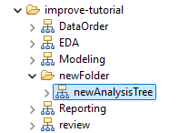

‘newAnalysisTree’ added to folder ‘newFolder’ inside ‘improve-tutorial’

## 10.3 createStep()

`createStep()` creates a new step under a specified analysis tree. Optionally, the step can be added as a child step to an already existing step.

**create new step in analysis tree ‘newAnalysisTree’**

```r
identNewAnalysisTree <- identNewFolder %>% loadChildResources()  %>%
select(data) %>%
unnest_wider(data) %>%
filter(name=="newAnalysisTree") %>%
pull(entityId)
identNewAnalysisTree
## [1] "envhost1.hc.scintecodev.internal-5310:AT-75704"

createStep(treeIdent=identNewAnalysisTree, parentStepIdent = NULL, toolId = NULL)
##                         resourceId   comment                resourceVersionId nodeType   name                         parentId deleted entityId entityVersionId                       revisionId lastModifiedOn                 lastModifiedById fileSize hasChildren hasChildrenIncludingFiles                                               path outdatedLink runStatus keyStep baseModel fullModel finalModel referenceModel                        ownedById processType processName  lastModifiedOnDate isVersion
## 1 E69D3CA25007484CAB17B5EFB4EE73CC improveRW D136979C98994486A109EBC26083A4EE     Step Step 1 7EC96470CA4144AC98FCE93F56C6A151   FALSE ST-75705      ST-75705-1 41AC5CFF24674DDC8A37B891F66A3496   1.750839e+12 1594E8ED57E6C30BE063030011ACA58C        0       FALSE                     FALSE /improve-tutorial/newFolder/newAnalysisTree/Step 1        FALSE   INITIAL   FALSE     FALSE     FALSE      FALSE          FALSE 1594E8ED57E6C30BE063030011ACA58C        main        Main 2025-06-25 10:08:18     FALSE
```

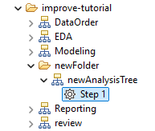

‘Step 1’ added to analysis tree ‘newAnalysisTree’

# 11 delete()

`delete()` deletes a resource by its ident. The function is used to delete folders, analysis trees, and steps.

**delete ‘newFolder’ folder**

```r
delete(res=identNewFolder) #delete folder 'newFolder' inside 'improve-tutorial'
## [1] TRUE
```

# 12 retrieve functions

There are three `retrieve` functions: `retrieveStep()`, `retrieveMainProcess()`, and `retrieveWorkflow()`. All three functions retrieve data held in the `stepCache` environment (in-memory only), and do not access the repository as stored on the server (in contrast to e.g. `loadResource()` or `loadChildResources()`).

## 12.1 retrieveStep()

`retrireveStep()` retrieves a step’s data by its handle. Critically, the function only retrieves the data which is stored in the environement `stepCache` and not as stored on the server (in-memory only). It’s essentially a wrapper for `get0` with `stepCache` provided as a constant. `retrieveStep()` returns a data frame containing the following columns: `handle`, `processes`, `treeIdent`, `treeName`, `treePath`, `description`, `entityId`, `remoteFiles`, `workflowHandle`, and `rationale`.

Important distinction: This is different from `loadResource()` - `retrieveStep()`works with workflow handles in memory, while `loadResource()` loads actual steps from the repository.

**Function definition**

```r
retrieveStep <- function(stepHandle) {
  get0(stepHandle,envir=stepCache)
}
```

**Use retrieveStep**

```r
stepHandle_ATDataOrder_Step3 <- workflowTargetStep %>%
    filter(entityId == "ST-54627") %>%
    pull(handle) # get handle of AT Data Order Step 3

stepHandle_ATDataOrder_Step3
## [1] "351ecb0b-93ff-4e0c-9a82-8e173185ae7e"

stepData <- retrieveStep(stepHandle = stepHandle_ATDataOrder_Step3) # Step 3 of Data Order

class(stepData)
## [1] "data.frame"
glimpse(stepData)
## Rows: 1
## Columns: 10
## $ handle         <chr> "351ecb0b-93ff-4e0c-9a82-8e173185ae7e"
## $ processes      <list> [<data.frame[1 x 12]>]
## $ treeIdent      <chr> "98C32486D1F6462793768B22909ED58E"
## $ treeName       <chr> "DataOrder"
## $ treePath       <chr> "/improve-tutorial"
## $ description    <chr> "Checks data set for missing data"
## $ entityId       <chr> "ST-54627"
## $ remoteFiles    <list> [<tbl_df[9 x 9]>]
## $ workflowHandle <chr> "c50e1e73-99dd-4aa5-9243-61577f9e909e"
## $ rationale      <chr> "Ensures missing data are accounted for before proceeding with analysis."
names(stepData)
##  [1] "handle"         "processes"      "treeIdent"      "treeName"       "treePath"       "description"    "entityId"       "remoteFiles"    "workflowHandle" "rationale"
```

## 12.2 retrieveMainProcess()

`retrieveMainProcess()` is a function that retrieves the main process of a step via the step’s handle in the `stepCache` environment. The function first calls `retrieveStep()`, then extracts, if available, the main process data. If no main process is found, it returns NULL.

**Function definition**

```r
retrieveMainProcess <- function(stepHandle) {
  stepData <- retrieveStep(stepHandle)
  processes <- stepData$processes[[1]]
  if (nrow(processes)>0 && ("main" %in% processes$processType)) {
    return(processes[processes$processType=="main",])
  }
  return(NULL)
}
```

**Demonstrate retrieveMainProcess**

```r
# get handle of AT Data Order Step
stepHandle_ATDataOrder_Step3 <- workflowTargetStep %>%
    filter(entityId == "ST-54627") %>%
    pull(handle)

# use function
mainProcess_ATDataOrder_Step3 <- retrieveMainProcess(stepHandle = stepHandle_ATDataOrder_Step3)

# check results
class(mainProcess_ATDataOrder_Step3)
## [1] "data.frame"
glimpse(mainProcess_ATDataOrder_Step3)
## Rows: 1
## Columns: 12
## $ handle                 <chr> "45B3491DF8A74932B479A8B461AB3B6F"
## $ runserverName          <chr> "runserver"
## $ toolName               <chr> "rs4robot_desktop-pmalkg2_cflandorfer"
## $ runserverToolName      <chr> "rs4robot_desktop-pmalkg2_cflandorfer"
## $ toolDeletePatterns     <chr> ".config\r\n.local\r\n.RData\r\n.Rhistory\r\nconf.json\r\nrstudio\r\nshare\r\ntemp"
## $ toolStreamablePatterns <chr> "*.txt\r\n*.out\r\n*.Rout"
## $ selected               <lgl> TRUE
## $ gridTool               <lgl> TRUE
## $ main                   <lgl> TRUE
## $ name                   <chr> "Main"
## $ processType            <chr> "main"
## $ position               <int> 1
mainProcess_ATDataOrder_Step3
##                             handle runserverName                             toolName                    runserverToolName                                                                toolDeletePatterns   toolStreamablePatterns selected gridTool main name processType position
## 1 45B3491DF8A74932B479A8B461AB3B6F     runserver rs4robot_desktop-pmalkg2_cflandorfer rs4robot_desktop-pmalkg2_cflandorfer .config\r\n.local\r\n.RData\r\n.Rhistory\r\nconf.json\r\nrstudio\r\nshare\r\ntemp *.txt\r\n*.out\r\n*.Rout     TRUE     TRUE TRUE Main        main        1
```

## 12.3 retrieveWorkflow()

For a description of `retrieveWorkflow()` see the above at Section 3.1.

```r
knitr::knit_exit()
```